# Bellabeat Case Study

Kittima R.

2025-03-03

# Bellabeat Fitness Tracking Analysis

**Skills Used:** R (ggplot2, dplyr), Data Visualization  
**Dataset:** [FitBit Fitness Tracker Data](https://www.kaggle.com/datasets/arashnic/fitbit)

## Business Task

Bellabeat wants to gain insights from **smart device usage trends** to **improve customer engagement and marketing strategy**.

## Data Preparation

```r
# Install necessary packages (only need to run once)
install.packages("tidyverse")
install.packages("lubridate")
```

```r
install.packages("ggplot2")
install.packages("skimr")
# Load libraries
library(tidyverse)
library(lubridate)
library(ggplot2)
library(skimr)
```

### Load and Inspect Data

```r
# Read datasets
daily_activity <- read.csv("dailyActivity_merged.csv")
sleep_day <- read.csv("sleepDay_merged.csv")

# View structure
str(daily_activity)
```

```
## 'data.frame':    940 obs. of  15 variables:
##  $ Id                      : num  1.5e+09 1.5e+09 1.5e+09 1.5e+09 1.5e+09 ...
##  $ ActivityDate            : chr  "4/12/2016" "4/13/2016" "4/14/2016" "4/15/2016" ...
##  $ TotalSteps              : int  13162 10735 10460 9762 12669 9705 13019 15506 10544 9819 ...
##  $ TotalDistance           : num  8.5 6.97 6.74 6.28 8.16 ...
##  $ TrackerDistance         : num  8.5 6.97 6.74 6.28 8.16 ...
##  $ LoggedActivitiesDistance: num  0 0 0 0 0 0 0 0 0 0 ...
##  $ VeryActiveDistance      : num  1.88 1.57 2.44 2.14 2.71 ...
##  $ ModeratelyActiveDistance: num  0.55 0.69 0.4 1.26 0.41 ...
##  $ LightActiveDistance     : num  6.06 4.71 3.91 2.83 5.04 ...
##  $ SedentaryActiveDistance : num  0 0 0 0 0 0 0 0 0 0 ...
##  $ VeryActiveMinutes       : int  25 21 30 29 36 38 42 50 28 19 ...
##  $ FairlyActiveMinutes     : int  13 19 11 34 10 20 16 31 12 8 ...
##  $ LightlyActiveMinutes    : int  328 217 181 209 221 164 233 264 205 211 ...
##  $ SedentaryMinutes        : int  728 776 1218 726 773 539 1149 775 818 838 ...
##  $ Calories                : int  1985 1797 1776 1745 1863 1728 1921 2035 1786 1775 ...
```

```r
str(sleep_day)
```

```
## 'data.frame':    413 obs. of  5 variables:
##  $ Id                : num  1.5e+09 1.5e+09 1.5e+09 1.5e+09 1.5e+09 ...
##  $ SleepDay          : chr  "4/12/2016 12:00:00 AM" "4/13/2016 12:00:00 AM" "4/15/2016 12:00:00 AM" "4/16/2016 12:00:00 AM" ...
##  $ TotalSleepRecords : int  1 2 1 2 1 1 1 1 1 1 ...
##  $ TotalMinutesAsleep: int  327 384 412 340 700 304 360 325 361 430 ...
##  $ TotalTimeInBed    : int  346 407 442 367 712 320 377 364 384 449 ...
```

```r
# Check missing values
colSums(is.na(daily_activity))
```

```
##                       Id             ActivityDate               TotalSteps
##                        0                        0                        0
##            TotalDistance          TrackerDistance LoggedActivitiesDistance
##                        0                        0                        0
##       VeryActiveDistance ModeratelyActiveDistance      LightActiveDistance
##                        0                        0                        0
##  SedentaryActiveDistance        VeryActiveMinutes      FairlyActiveMinutes
##                        0                        0                        0
##     LightlyActiveMinutes         SedentaryMinutes                 Calories
##                        0                        0                        0
```

```r
colSums(is.na(sleep_day))
```

```
##                 Id           SleepDay  TotalSleepRecords TotalMinutesAsleep
##                  0                  0                  0                  0
##     TotalTimeInBed
##                  0
```

### Data Cleaning

```r
# Convert date columns to Date format
daily_activity$ActivityDate <- as.Date(daily_activity$ActivityDate, format="%m/%d/%Y")
sleep_day$SleepDay <- as.Date(sleep_day$SleepDay, format="%m/%d/%Y")

# Remove duplicates
sleep_day <- sleep_day %>% distinct() %>% drop_na()

# Merge datasets on Id and Date
merged_data <- merge(daily_activity, sleep_day, by.x=c("Id", "ActivityDate"), by.y=c("Id", "SleepDay"), all.x=TRUE)
```

## Exploratory Data Analysis (EDA)

```r
# Summary statistics
summary(merged_data %>% select(TotalSteps, TotalDistance, SedentaryMinutes, Calories, TotalSleepRecords, TotalMinutesAsleep, TotalTimeInBed))
```

```
##    TotalSteps    TotalDistance    SedentaryMinutes    Calories
##  Min.   :    0   Min.   : 0.000   Min.   :   0.0   Min.   :   0
##  1st Qu.: 3790   1st Qu.: 2.620   1st Qu.: 729.8   1st Qu.:1828
##  Median : 7406   Median : 5.245   Median :1057.5   Median :2134
##  Mean   : 7638   Mean   : 5.490   Mean   : 991.2   Mean   :2304
##  3rd Qu.:10727   3rd Qu.: 7.713   3rd Qu.:1229.5   3rd Qu.:2793
##  Max.   :36019   Max.   :28.030   Max.   :1440.0   Max.   :4900
##
##  TotalSleepRecords TotalMinutesAsleep TotalTimeInBed
##  Min.   :1.000     Min.   : 58.0      Min.   : 61.0
##  1st Qu.:1.000     1st Qu.:361.0      1st Qu.:403.8
##  Median :1.000     Median :432.5      Median :463.0
##  Mean   :1.119     Mean   :419.2      Mean   :458.5
##  3rd Qu.:1.000     3rd Qu.:490.0      3rd Qu.:526.0
##  Max.   :3.000     Max.   :796.0      Max.   :961.0
##  NA's   :530       NA's   :530        NA's   :530
```

### Visualizing Key Insights

#### Distribution of Daily Steps

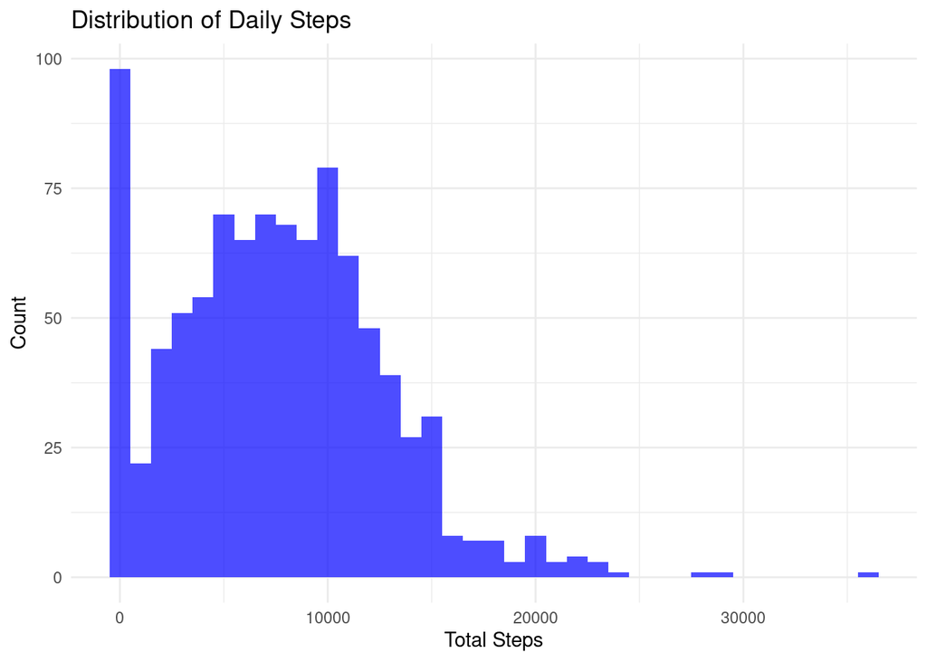

```r
ggplot(merged_data, aes(x = TotalSteps)) +
  geom_histogram(binwidth = 1000, fill = "blue", alpha = 0.7) +
  labs(title = "Distribution of Daily Steps", x = "Total Steps", y = "Count") +
  theme_minimal()
```

#### Relationship Between Steps and Sedentary Minutes

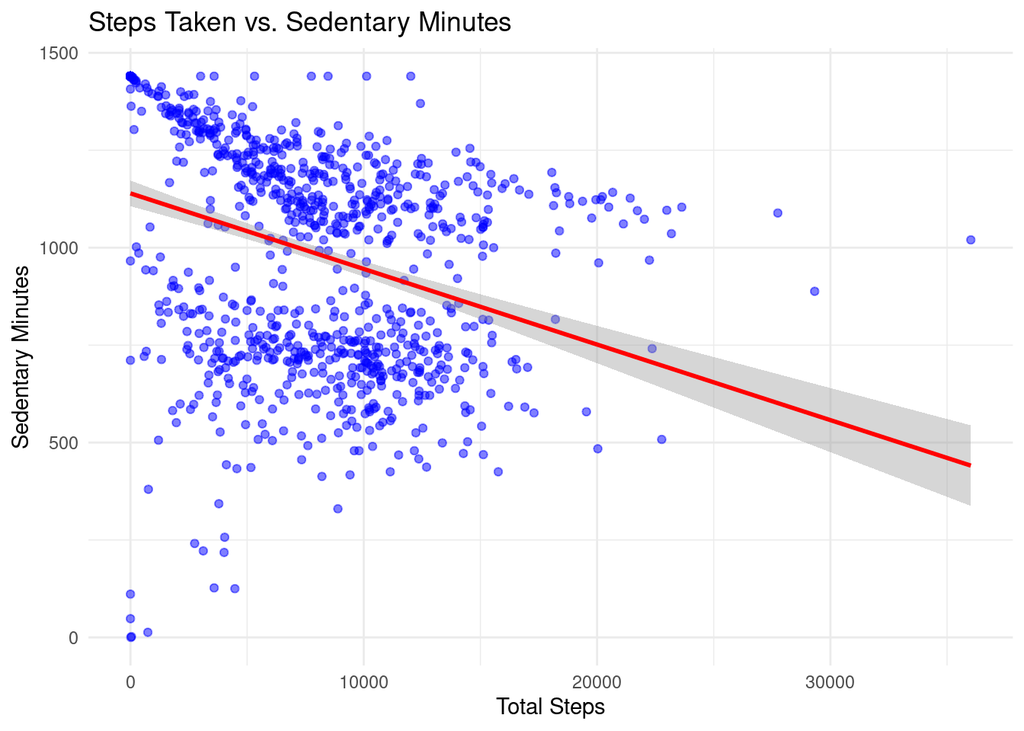

```r
ggplot(merged_data, aes(x = TotalSteps, y = SedentaryMinutes)) +
  geom_point(alpha = 0.5, color = "blue") +
  geom_smooth(method = "lm", color = "red") +
  labs(title = "Steps Taken vs. Sedentary Minutes", x = "Total Steps", y = "Sedentary Minutes") +
  theme_minimal()
```

#### Sleep vs. Time in Bed

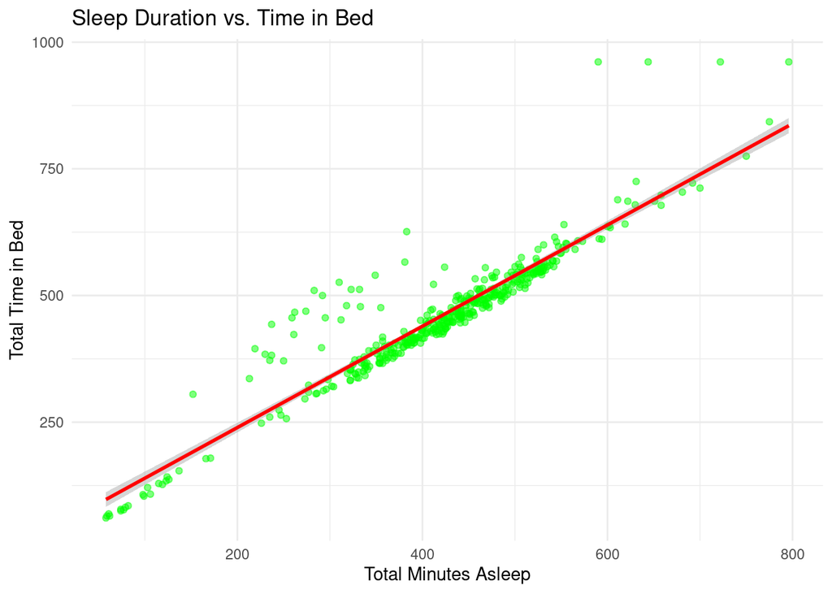

```r
ggplot(merged_data, aes(x = TotalMinutesAsleep, y = TotalTimeInBed)) +
  geom_point(alpha = 0.5, color = "green") +
  geom_smooth(method = "lm", color = "red") +
  labs(title = "Sleep Duration vs. Time in Bed", x = "Total Minutes Asleep", y = "Total Time in Bed") +
  theme_minimal()
```

## Segmenting Users by Activity Level

```r
# Categorizing users into activity levels
merged_data <- merged_data %>%
  mutate(ActivityLevel = case_when(
    TotalSteps < 5000 ~ "Low", # Sedentary
    TotalSteps >= 5000 & TotalSteps < 10000 ~ "Moderate",  # Active
    TotalSteps >= 10000 ~ "High"  # Very Active
  ))
```

#### Distribution of Activity Levels

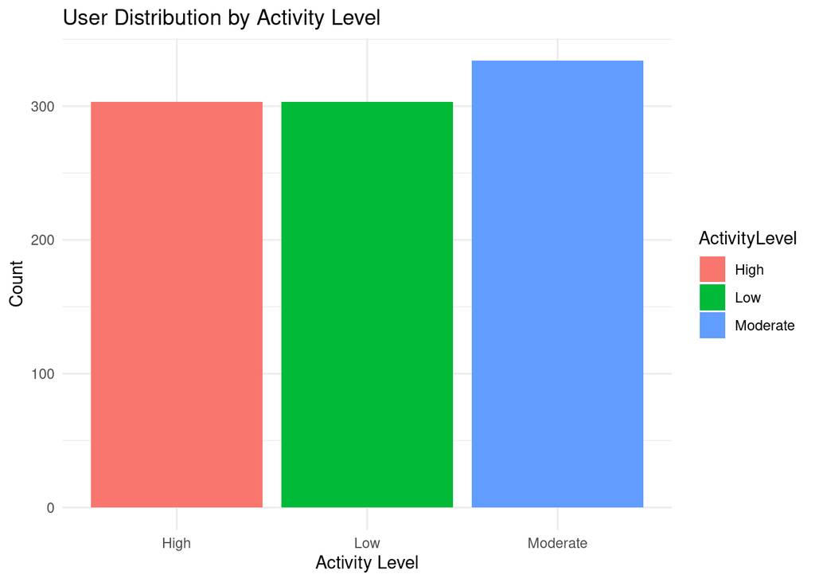

```r
ggplot(merged_data, aes(x = ActivityLevel, fill = ActivityLevel)) +
  geom_bar() +
  labs(title = "User Distribution by Activity Level", x = "Activity Level", y = "Count") +
  theme_minimal()
```

#### Steps vs. Sleep Analysis

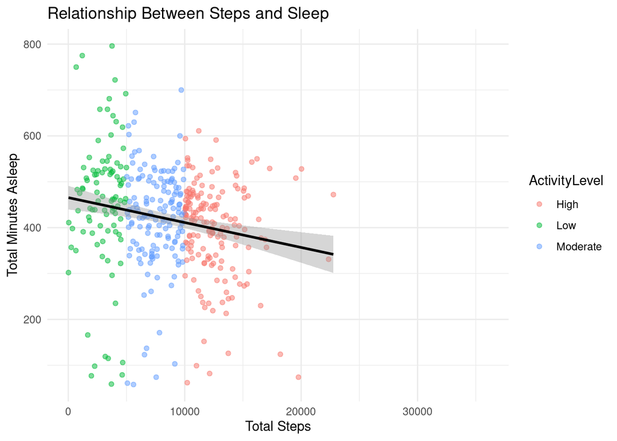

```r
ggplot(merged_data, aes(x = TotalSteps, y = TotalMinutesAsleep, color = ActivityLevel)) +
  geom_point(alpha = 0.5) +
  geom_smooth(method = "lm", color = "black") +
  labs(title = "Relationship Between Steps and Sleep", x = "Total Steps", y = "Total Minutes Asleep") +
  theme_minimal()
```

#### Activity Trends by Day of the Week

```r
# Extract day of the week
merged_data$DayOfWeek <- weekdays(merged_data$ActivityDate)
```

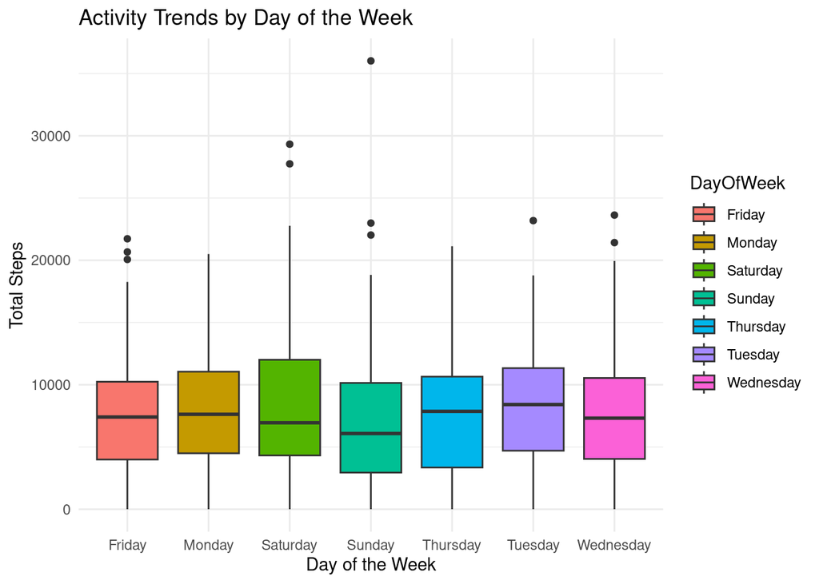

```r
ggplot(merged_data, aes(x = DayOfWeek, y = TotalSteps, fill = DayOfWeek)) +
  geom_boxplot() +
  labs(title = "Activity Trends by Day of the Week", x = "Day of the Week", y = "Total Steps") +
  theme_minimal()
```

## Summary Table of Activity Levels

```r
merged_data %>%
  count(ActivityLevel) %>%
  rename("Activity Level" = ActivityLevel, "User Count" = n)
```

```
##   Activity Level User Count
## 1           High        303
## 2            Low        303
## 3       Moderate        334
```

## Insights & Recommendations

- Users with **higher step counts** tend to be more active and burn more calories.
- There is a **strong correlation between sleep duration and time in bed**, but some users may have poor sleep efficiency.
- **Sedentary behavior remains high**, even for active users, indicating a need for targeted movement reminders.
- **Encourage Low & Moderate Activity Users** → Position Bellabeat as an entry-level fitness tracker to help users gradually increase their steps.
- **Support High Activity Users** → Market advanced analytics to users already taking 10,000+ steps.
- **Leverage Sedentary Trends** → Introduce features like **“Active Hour Alerts”** to encourage users to move more.
- **Promote Sleep & Recovery Features** → Market Bellabeat as a wellness tool, not just a fitness tracker.
- **Weekend vs. Weekday Activity Campaigns** → Adjust marketing messages based on activity patterns.

🚀 **Next Steps:**  
- Further investigate user segments (e.g., group users into “low, moderate, high activity”)  
- Explore seasonal trends in fitness tracker usage  
- Develop business recommendations for Bellabeat based on deeper insights